# HW8_B66084

Luis Gerson Noboa Martillo

16 de abril de 2017

# Exercise 1

```
##     outlook temp humidity windy play
## 1     Sunny  Hot     High False   No
## 2     Sunny  Hot     High  True   No
## 3  Overcast  Hot     High False  Yes
## 4     Rainy Mild     High False  Yes
## 5     Rainy Cool   Normal False  Yes
## 6     Rainy Cool   Normal  True   No
## 7  Overcast Cool   Normal  True  Yes
## 8     Sunny Mild     High False   No
## 9     Sunny Cool   Normal False  Yes
## 10    Rainy Mild   Normal False  Yes
## 11    Sunny Mild   Normal  True  Yes
## 12 Overcast Mild     High  True  Yes
## 13 Overcast  Hot   Normal False  Yes
## 14    Rainy Mild     High  True   No
```

Formula for calculating entropy

```r
entropySingle <- function(data, column){
  frequencies = count(data, column)
  totalCount = sum(frequencies$freq)
  entropy = 0

  for (i in 1:nrow(frequencies)){
    row = frequencies[i,]
    probability = row$freq / totalCount
    entropy = ((- probability) * log2(probability)) + entropy
  }
  return(entropy)
}

entropyNumbers <- function(n1, n2){
  total = n1 + n2
  prob1 = n1/total
  prob2 = n2/total
  entropy = ((- prob1) * log2(prob1)) + ((- prob2) * log2(prob2))

  if (is.nan(entropy)){
    entropy = 0
  }
  return(entropy)
}

entropyColumns <- function(data){
  entropy = 0
  total = sum(data)
  for (i in 1:nrow(data)){
    partialTotal = sum(data[i,])

    row = data[i,]
    n1 = as.numeric(row[1])
    n2 = as.numeric(row[2])
    probability = partialTotal / total
    partEntropy = entropyNumbers(n1, n2)
    entropy = (probability * partEntropy) + entropy
  }

  return(entropy)
}
```

## First level

First, the calculation of the play entropy is done.

```r
playEntropy = entropySingle(info, "play")
paste("Play entropy:", playEntropy)
```

```
## [1] "Play entropy: 0.940285958670631"
```

Then the combination of play with the other columns is performed.

### Outlook

```
##          No Yes
## Sunny     3   2
## Overcast  0   4
## Raining   2   3
```

```
## [1] "Entropy: 0.693536138896192"
```

```
## [1] "Gain:  0.246749819774439"
```

### Temperature

```
##      No Yes
## Hot   2   2
## Mild  2   4
## Cool  1   3
```

```
## [1] "Entropy: 0.911063393011676"
```

```
## [1] "Gain:  0.0292225656589546"
```

### Humidity

```
##        No Yes
## High    4   3
## Normal  1   6
```

```
## [1] "Entropy: 0.78845045730829"
```

```
## [1] "Gain:  0.151835501362341"
```

### Windy

```
##        No Yes
## High    2   6
## Normal  3   3
```

```
## [1] "Entropy: 0.892158928262362"
```

```
## [1] "Gain:  0.0481270304082693"
```

We can see that outlook has the biggest gain, so it should be at the top of the tree.

## Second level

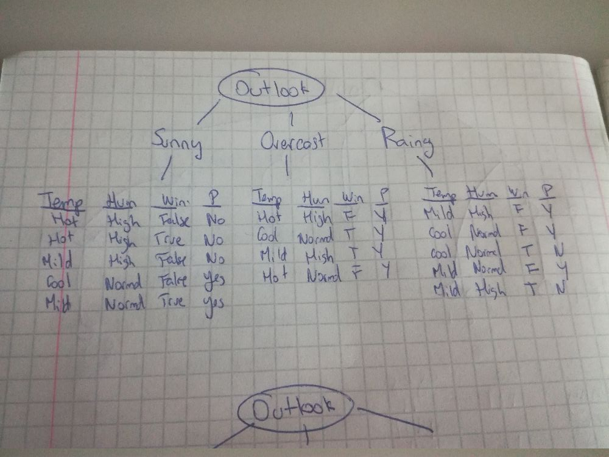

As we can see, there’s a tendency in the data, in which, in the case of sunny, the output is No every time humidity is High and Yes if humidity is Normal. In the case of overcast, it is Yes regardless of what happens with the other choices. Also, for rainy, Yes is selected if wind is false, and No if wind is true.

Therefore, we can make the tree in this way:

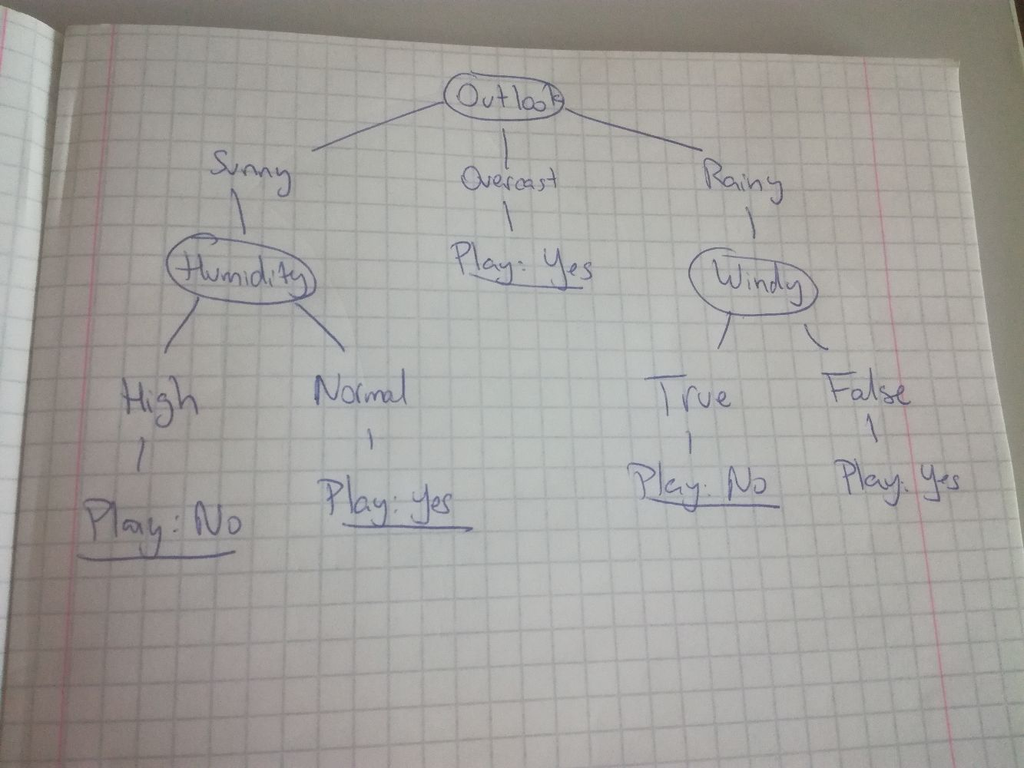

With this arrangement, the example:

Sunny Cool High TRUE

Would yield Play: No.

# Exercise 2

To calculate this, we use the formula in order to get the NB value for Yes when the conditions of the example happen, and then with no. Then it’s only a matter of getting the probabilities and calculating the values through simple math.

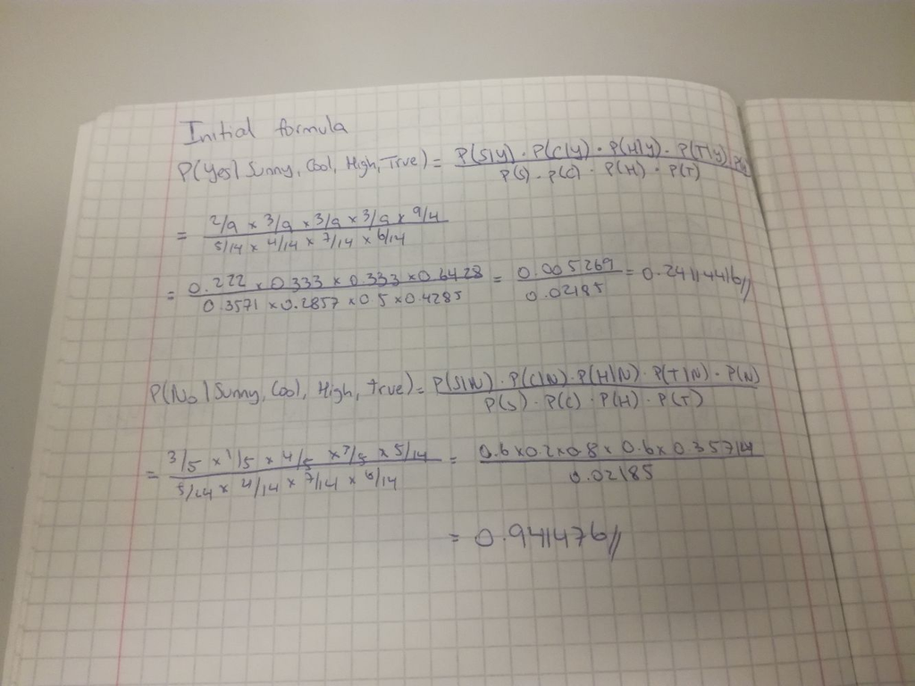

Because the No value yields a much higher score, then we can conclude that Naive Bayes predicts that the value will be No, and that the probability that it is true is a little more than 94%.

# Exercise 3

For this exercise, values were transformed to numeric scores. If the value was the same as the example we have to predict, then we changed it to 0. Else, we changed it to one. I tried to change it to one and two, depending on the column (ex: Sunny 0, Overcast 1, Rainy 2), but results got very messy then.

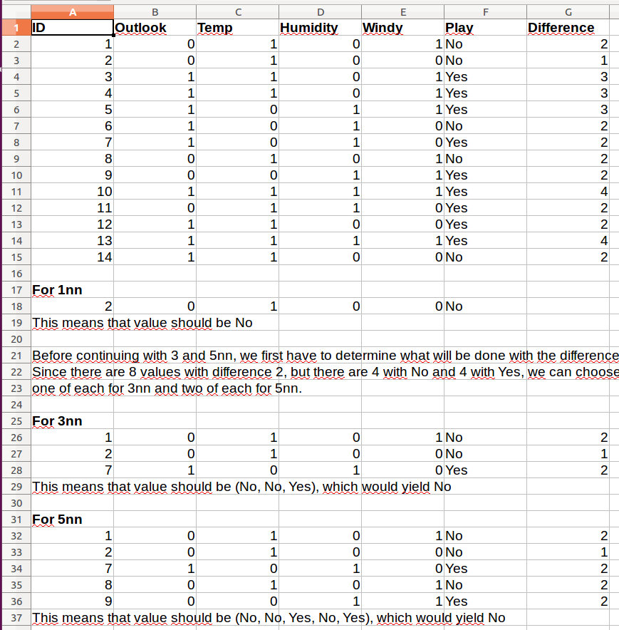

# Exercise 4

## Split 1

### Decision Tree

```r
treeGeneration(train1, test1)
```

```
## [1] "Information gain"
##           attr_importance
## age          0.0114008545
## job          0.0085733847
## marital      0.0021586268
## education    0.0024100470
## default      0.0003025188
## balance      0.0054955773
## housing      0.0097739309
## loan         0.0027687964
## contact      0.0133598174
## day          0.0049971356
## month        0.0234676256
## duration     0.0723537373
## campaign     0.0040692839
## pdays        0.0251553648
## previous     0.0118462581
## poutcome     0.0295510230
## [1] "Tree"
## n= 36235
##
## node), split, n, loss, yval, (yprob)
##       * denotes terminal node
##
##  1) root 36235 4276 no (0.88199255 0.11800745)
##    2) duration< 521.5 32216 2504 no (0.92227465 0.07772535)
##      4) poutcome=failure,other,unknown 31155 1848 no (0.94068368 0.05931632) *
##      5) poutcome=success 1061  405 yes (0.38171536 0.61828464)
##       10) duration< 162.5 289   91 no (0.68512111 0.31487889) *
##       11) duration>=162.5 772  207 yes (0.26813472 0.73186528) *
##    3) duration>=521.5 4019 1772 no (0.55909430 0.44090570)
##      6) duration< 807.5 2475  870 no (0.64848485 0.35151515)
##       12) poutcome=failure,other,unknown 2368  784 no (0.66891892 0.33108108) *
##       13) poutcome=success 107   21 yes (0.19626168 0.80373832) *
##      7) duration>=807.5 1544  642 yes (0.41580311 0.58419689) *
## [1] "Confusion Matrix for Tree"
## Confusion Matrix and Statistics
##
##           Reference
## Prediction   no  yes
##        no  7753  675
##        yes  210  338
##
##                Accuracy : 0.9014
##                  95% CI : (0.895, 0.9075)
##     No Information Rate : 0.8871
##     P-Value [Acc > NIR] : 7.416e-06
##
##                   Kappa : 0.3843
##  Mcnemar's Test P-Value : < 2.2e-16
##
##             Sensitivity : 0.9736
##             Specificity : 0.3337
##          Pos Pred Value : 0.9199
##          Neg Pred Value : 0.6168
##              Prevalence : 0.8871
##          Detection Rate : 0.8637
##    Detection Prevalence : 0.9389
##       Balanced Accuracy : 0.6536
##
##        'Positive' Class : no
##
```

### Naive Bayes

```r
nbGeneration(train1, test1)
```

```
## [1] "NB"
##
## Naive Bayes Classifier for Discrete Predictors
##
## Call:
## naiveBayes.default(x = X, y = Y, laplace = laplace)
##
## A-priori probabilities:
## Y
##        no       yes
## 0.8819925 0.1180075
##
## Conditional probabilities:
##      age
## Y         [,1]     [,2]
##   no  40.83069 10.17191
##   yes 41.67259 13.45561
##
##      job
## Y          admin. blue-collar entrepreneur   housemaid  management
##   no  0.113676899 0.224975750  0.033417817 0.028317532 0.205513314
##   yes 0.118334892 0.134003742  0.023620206 0.019878391 0.247427502
##      job
## Y         retired self-employed    services     student  technician
##   no  0.043618386   0.034669420 0.094996715 0.016771488 0.169999061
##   yes 0.098690365   0.035781104 0.068989710 0.051683817 0.155986904
##      job
## Y      unemployed     unknown
##   no  0.027316249 0.006727369
##   yes 0.039522919 0.006080449
##
##      marital
## Y      divorced   married    single
##   no  0.1148033 0.6114709 0.2737257
##   yes 0.1188026 0.5180075 0.3631899
##
##      education
## Y        primary  secondary   tertiary    unknown
##   no  0.15657561 0.51794487 0.28486498 0.04061454
##   yes 0.11482694 0.46141254 0.37652011 0.04724041
```

[output cut: 81 more lines]

```
##
##                   Kappa : 0.429
##  Mcnemar's Test P-Value : 0.001095
##
##             Sensitivity : 0.9258
##             Specificity : 0.5232
##          Pos Pred Value : 0.9385
##          Neg Pred Value : 0.4728
##              Prevalence : 0.8871
##          Detection Rate : 0.8213
##    Detection Prevalence : 0.8751
##       Balanced Accuracy : 0.7245
##
##        'Positive' Class : no
##
```

## Split 2

### Decision Tree

```r
treeGeneration(train2, test2)
```

```
## [1] "Information gain"
##           attr_importance
## age          0.0113446550
## job          0.0085535384
## marital      0.0020635569
## education    0.0028137162
## default      0.0002840637
## balance      0.0055025321
## housing      0.0093734047
## loan         0.0024355392
## contact      0.0137782893
## day          0.0045927096
## month        0.0245252317
## duration     0.0714670482
## campaign     0.0041040358
## pdays        0.0250642712
## previous     0.0119857358
## poutcome     0.0287258672
## [1] "Tree"
## n= 36209
##
## node), split, n, loss, yval, (yprob)
##       * denotes terminal node
##
##  1) root 36209 4228 no (0.88323345 0.11676655)
##    2) duration< 472.5 31472 2300 no (0.92691917 0.07308083)
##      4) poutcome=failure,other,unknown 30465 1687 no (0.94462498 0.05537502) *
##      5) poutcome=success 1007  394 yes (0.39126117 0.60873883)
##       10) duration< 132 199   45 no (0.77386935 0.22613065) *
##       11) duration>=132 808  240 yes (0.29702970 0.70297030) *
##    3) duration>=472.5 4737 1928 no (0.59299134 0.40700866)
##      6) duration< 780.5 3095  998 no (0.67754443 0.32245557)
##       12) poutcome=failure,other,unknown 2951  884 no (0.70044053 0.29955947) *
##       13) poutcome=success 144   30 yes (0.20833333 0.79166667) *
##      7) duration>=780.5 1642  712 yes (0.43361754 0.56638246) *
## [1] "Confusion Matrix for Tree"
## Confusion Matrix and Statistics
##
##           Reference
## Prediction   no  yes
##        no  7690  660
##        yes  251  401
##
##                Accuracy : 0.8988
##                  95% CI : (0.8924, 0.905)
##     No Information Rate : 0.8821
##     P-Value [Acc > NIR] : 3.043e-07
##
##                   Kappa : 0.4158
##  Mcnemar's Test P-Value : < 2.2e-16
##
##             Sensitivity : 0.9684
##             Specificity : 0.3779
##          Pos Pred Value : 0.9210
##          Neg Pred Value : 0.6150
##              Prevalence : 0.8821
##          Detection Rate : 0.8543
##    Detection Prevalence : 0.9276
##       Balanced Accuracy : 0.6732
##
##        'Positive' Class : no
##
```

### Naive Bayes

```r
nbGeneration(train2, test2)
```

```
## [1] "NB"
##
## Naive Bayes Classifier for Discrete Predictors
##
## Call:
## naiveBayes.default(x = X, y = Y, laplace = laplace)
##
## A-priori probabilities:
## Y
##        no       yes
## 0.8832335 0.1167665
##
## Conditional probabilities:
##      age
## Y         [,1]     [,2]
##   no  40.83024 10.15952
##   yes 41.59130 13.41984
##
##      job
## Y          admin. blue-collar entrepreneur   housemaid  management
##   no  0.114474219 0.228510678  0.034270348 0.028548200 0.202995529
##   yes 0.117786187 0.132686850  0.022942289 0.021286660 0.242667928
##      job
## Y         retired self-employed    services     student  technician
##   no  0.043213158   0.034864451 0.094493606 0.016322191 0.168475032
##   yes 0.097209082   0.036187323 0.071428571 0.052034059 0.160832545
##      job
## Y      unemployed     unknown
##   no  0.027453801 0.006378787
##   yes 0.037606433 0.007332072
##
##      marital
## Y      divorced   married    single
##   no  0.1155061 0.6124887 0.2720053
##   yes 0.1158940 0.5229423 0.3611637
##
##      education
## Y       primary secondary  tertiary   unknown
##   no  0.1586254 0.5211219 0.2806666 0.0395860
##   yes 0.1083254 0.4673605 0.3755913 0.0487228
```

[output cut: 81 more lines]

```
##
##                   Kappa : 0.4222
##  Mcnemar's Test P-Value : 4.468e-05
##
##             Sensitivity : 0.9193
##             Specificity : 0.5269
##          Pos Pred Value : 0.9357
##          Neg Pred Value : 0.4658
##              Prevalence : 0.8821
##          Detection Rate : 0.8109
##    Detection Prevalence : 0.8667
##       Balanced Accuracy : 0.7231
##
##        'Positive' Class : no
##
```

## Split 3

### Decision Tree

```r
treeGeneration(train3, test3)
```

```
## [1] "Information gain"
##           attr_importance
## age          0.0115392344
## job          0.0080804185
## marital      0.0017998447
## education    0.0022381950
## default      0.0003036449
## balance      0.0057384135
## housing      0.0092522419
## loan         0.0027963636
## contact      0.0135309541
## day          0.0052691372
## month        0.0244620026
## duration     0.0716583148
## campaign     0.0037615216
## pdays        0.0245246041
## previous     0.0115645705
## poutcome     0.0283707885
## [1] "Tree"
## n= 36055
##
## node), split, n, loss, yval, (yprob)
##       * denotes terminal node
##
##  1) root 36055 4198 no (0.88356677 0.11643323)
##    2) duration< 521.5 32079 2448 no (0.92368839 0.07631161)
##      4) poutcome=failure,other,unknown 31085 1834 no (0.94100048 0.05899952) *
##      5) poutcome=success 994  380 yes (0.38229376 0.61770624)
##       10) duration< 162.5 271   82 no (0.69741697 0.30258303) *
##       11) duration>=162.5 723  191 yes (0.26417704 0.73582296) *
##    3) duration>=521.5 3976 1750 no (0.55985915 0.44014085)
##      6) duration< 834.5 2549  922 no (0.63828953 0.36171047)
##       12) poutcome=failure,other,unknown 2436  831 no (0.65886700 0.34113300) *
##       13) poutcome=success 113   22 yes (0.19469027 0.80530973) *
##      7) duration>=834.5 1427  599 yes (0.41976174 0.58023826) *
## [1] "Confusion Matrix for Tree"
## Confusion Matrix and Statistics
##
##           Reference
## Prediction   no  yes
##        no  7877  718
##        yes  188  373
##
##                Accuracy : 0.901
##                  95% CI : (0.8947, 0.9071)
##     No Information Rate : 0.8808
##     P-Value [Acc > NIR] : 5.163e-10
##
##                   Kappa : 0.4033
##  Mcnemar's Test P-Value : < 2.2e-16
##
##             Sensitivity : 0.9767
##             Specificity : 0.3419
##          Pos Pred Value : 0.9165
##          Neg Pred Value : 0.6649
##              Prevalence : 0.8808
##          Detection Rate : 0.8603
##    Detection Prevalence : 0.9387
##       Balanced Accuracy : 0.6593
##
##        'Positive' Class : no
##
```

### Naive Bayes

```r
nbGeneration(train3, test3)
```

```
## [1] "NB"
##
## Naive Bayes Classifier for Discrete Predictors
##
## Call:
## naiveBayes.default(x = X, y = Y, laplace = laplace)
##
## A-priori probabilities:
## Y
##        no       yes
## 0.8835668 0.1164332
##
## Conditional probabilities:
##      age
## Y         [,1]     [,2]
##   no  40.79885 10.15630
##   yes 41.74297 13.55751
##
##      job
## Y          admin. blue-collar entrepreneur   housemaid  management
##   no  0.113193333 0.225664689  0.034529303 0.028565151 0.204664595
##   yes 0.120533587 0.135540734  0.022629824 0.021200572 0.241067175
##      job
## Y         retired self-employed    services     student  technician
##   no  0.042659384   0.035941865 0.094673070 0.016887968 0.168942462
##   yes 0.097903764   0.034540257 0.071224393 0.050738447 0.161505479
##      job
## Y      unemployed     unknown
##   no  0.028094296 0.006183884
##   yes 0.037160553 0.005955217
##
##      marital
## Y      divorced   married    single
##   no  0.1148570 0.6103525 0.2747905
##   yes 0.1157694 0.5262030 0.3580276
##
##      education
## Y        primary  secondary   tertiary    unknown
##   no  0.15557020 0.52013686 0.28329723 0.04099570
##   yes 0.11481658 0.46569795 0.37089090 0.04859457
```

[output cut: 81 more lines]

```
##
##                   Kappa : 0.4317
##  Mcnemar's Test P-Value : 0.09382
##
##             Sensitivity : 0.9272
##             Specificity : 0.5142
##          Pos Pred Value : 0.9338
##          Neg Pred Value : 0.4887
##              Prevalence : 0.8808
##          Detection Rate : 0.8167
##    Detection Prevalence : 0.8746
##       Balanced Accuracy : 0.7207
##
##        'Positive' Class : no
##
```

## Split 4

### Decision Tree

```r
treeGeneration(train4, test4)
```

```
## [1] "Information gain"
##           attr_importance
## age          0.0112572941
## job          0.0078781224
## marital      0.0022818476
## education    0.0026390454
## default      0.0003251476
## balance      0.0051750650
## housing      0.0098949782
## loan         0.0025592349
## contact      0.0138708043
## day          0.0057362338
## month        0.0246465917
## duration     0.0716996937
## campaign     0.0039957255
## pdays        0.0258533827
## previous     0.0121764265
## poutcome     0.0292303204
## [1] "Tree"
## n= 36069
##
## node), split, n, loss, yval, (yprob)
##       * denotes terminal node
##
##  1) root 36069 4207 no (0.88336244 0.11663756)
##    2) duration< 472.5 31384 2276 no (0.92747897 0.07252103)
##      4) poutcome=failure,other,unknown 30394 1675 no (0.94489044 0.05510956) *
##      5) poutcome=success 990  389 yes (0.39292929 0.60707071)
##       10) duration< 132.5 204   45 no (0.77941176 0.22058824) *
##       11) duration>=132.5 786  230 yes (0.29262087 0.70737913) *
##    3) duration>=472.5 4685 1931 no (0.58783351 0.41216649)
##      6) duration< 647.5 2185  641 no (0.70663616 0.29336384)
##       12) poutcome=failure,other,unknown 2071  550 no (0.73442781 0.26557219) *
##       13) poutcome=success 114   23 yes (0.20175439 0.79824561) *
##      7) duration>=647.5 2500 1210 yes (0.48400000 0.51600000)
##       14) contact=telephone,unknown 826  335 no (0.59443099 0.40556901) *
##       15) contact=cellular 1674  719 yes (0.42951016 0.57048984) *
## [1] "Confusion Matrix for Tree"
## Confusion Matrix and Statistics
##
```

[output cut: 9 more lines]

```
##
##                   Kappa : 0.4145
##  Mcnemar's Test P-Value : < 2.2e-16
##
##             Sensitivity : 0.9653
##             Specificity : 0.3854
##          Pos Pred Value : 0.9213
##          Neg Pred Value : 0.5983
##              Prevalence : 0.8816
##          Detection Rate : 0.8510
##    Detection Prevalence : 0.9238
##       Balanced Accuracy : 0.6753
##
##        'Positive' Class : no
##
```

### Naive Bayes

```r
nbGeneration(train4, test4)
```

```
## [1] "NB"
##
## Naive Bayes Classifier for Discrete Predictors
##
## Call:
## naiveBayes.default(x = X, y = Y, laplace = laplace)
##
## A-priori probabilities:
## Y
##        no       yes
## 0.8833624 0.1166376
##
## Conditional probabilities:
##      age
## Y         [,1]     [,2]
##   no  40.85105 10.17994
##   yes 41.62776 13.47553
##
##      job
## Y          admin. blue-collar entrepreneur   housemaid  management
##   no  0.114211286 0.225032955  0.033990333 0.028121273 0.204601092
##   yes 0.120038032 0.134299976  0.022819111 0.019253625 0.248633230
##      job
## Y         retired self-employed    services     student  technician
##   no  0.044473040   0.033425397 0.095348691 0.017042245 0.169700584
##   yes 0.095555027   0.036605657 0.068932731 0.048728310 0.158782981
##      job
## Y      unemployed     unknown
##   no  0.027901576 0.006151528
##   yes 0.039695745 0.006655574
##
##      marital
## Y      divorced   married    single
##   no  0.1150273 0.6145879 0.2703848
##   yes 0.1200380 0.5177086 0.3622534
##
##      education
## Y        primary  secondary   tertiary    unknown
##   no  0.15639320 0.51861151 0.28469650 0.04029879
##   yes 0.11266936 0.45899691 0.38150701 0.04682672
```

[output cut: 81 more lines]

```
##
##                   Kappa : 0.4465
##  Mcnemar's Test P-Value : 9.675e-06
##
##             Sensitivity : 0.9213
##             Specificity : 0.5518
##          Pos Pred Value : 0.9387
##          Neg Pred Value : 0.4850
##              Prevalence : 0.8816
##          Detection Rate : 0.8123
##    Detection Prevalence : 0.8653
##       Balanced Accuracy : 0.7365
##
##        'Positive' Class : no
##
```